# 04 - Simple Regression Model

Murray McKechnie

14/5/2020

GLM Predicts deaths x days after initial outbreak given average age, GDP (PPP), and Obesity rate.

Other options:

Total Number of deaths t days after 1st infection. Total Number of deaths t days after infections crossed 0.1 per million people.

Could use t as a choice before fitting the model, or as an independent variable. In latter a linear model is not ideal, and perhaps a logistic growth model would be better.

# Select the countries for the models, and obtain their relevant variable values

We only choose countries that have reached a peak in Covid-19 deaths, have population > 3 million, and have experienced more than 50 Covid-19 deaths. We exclude China. They must also have data for all the variables used in the model.

```r
model_variables <- simple_model_data %>%
  group_by(Country) %>%
  mutate(average_gov_response = mean(case_when(days_since_deaths_crossed_0.1_per_million >= 0 & date <= "2020-05-09" ~ StringencyIndex,
                                               TRUE ~ NaN), na.rm = T)) %>%
  group_by(Country, Obesity_rate, gdp_estimate_ppp, Median_Age, population_size, peak_deaths_already_occurred_indicator,
           age_adjusted_risk, Density_km, Inequality_spatial_transformed, gov_response_at_0.1_deaths_per_million, average_gov_response) %>%
  mutate(total_deaths = max(total_deaths, na.rm = T)) %>%
  filter(deaths_5_day_averages == max(deaths_5_day_averages, na.rm = T)) %>% # Just keeps the day(s) of the peak for each country
  summarise(total_deaths_per_million = max(total_deaths_per_million, na.rm = T),
            smooth_new_deaths_per_million = max(deaths_5_day_averages, na.rm = T),
            total_deaths = max(total_deaths, na.rm = T)) %>%
  filter(!is.na(Obesity_rate) &
         #!is.na(gdp_estimate_ppp) &
         !is.na(total_deaths_per_million) &
         !is.na(age_adjusted_risk) &
         !(is.na(Density_km)) &
         !is.na(gov_response_at_0.1_deaths_per_million) &
         peak_deaths_already_occurred_indicator == 1 &
         population_size >= 3 &
         total_deaths >= 50 &
         Country != c("China")
         ) %>%
  mutate(combined_density_measure = Density_km * Inequality_spatial_transformed)
write.csv(model_variables, file = "04_Results/condensed_data_for_models.csv")
```

# Model 1: Predict total_deaths_per_million using age_adjusted_risk

```r
m1 <- glm(data = model_variables, family = Gamma("log"), formula = total_deaths_per_million ~ age_adjusted_risk)

summary(m1)
```

```
##
## Call:
## glm(formula = total_deaths_per_million ~ age_adjusted_risk, family = Gamma("log"),
##     data = model_variables)
##
## Deviance Residuals:
##     Min       1Q   Median       3Q      Max
## -2.9616  -1.6810  -0.9701   0.1249   3.3072
##
## Coefficients:
##                   Estimate Std. Error t value Pr(>|t|)
## (Intercept)       3.651081   0.269930  13.526   <2e-16 ***
## age_adjusted_risk 0.014653   0.005143   2.849   0.0056 **
## ---
## Signif. codes:  0 '***' 0.001 '**' 0.01 '*' 0.05 '.' 0.1 ' ' 1
##
## (Dispersion parameter for Gamma family taken to be 2.466269)
##
##     Null deviance: 189.13  on 79  degrees of freedom
## Residual deviance: 176.25  on 78  degrees of freedom
## AIC: 824.32
##
## Number of Fisher Scoring iterations: 11
```

## Compare fitted values to actual values

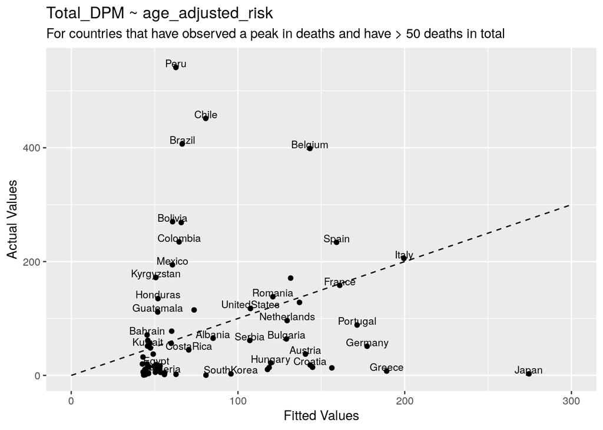

```r
ggplot(data = model_variables, aes(x = m1$fitted.values, y = total_deaths_per_million)) +
  geom_point() +
  geom_text(aes(label = Country), size = 3, check_overlap = T, nudge_y = 7) +
  geom_line(aes(y = seq(0, 300, length.out = dim(model_variables)[1]), x = seq(0, 300, length.out = dim(model_variables)[1])), linetype = "dashed") +
  labs(title = "Total_DPM ~ age_adjusted_risk",
       subtitle = "For countries that have observed a peak in deaths and have > 50 deaths in total",
       x = "Fitted Values",
       y = "Actual Values")
```

## Check residuals

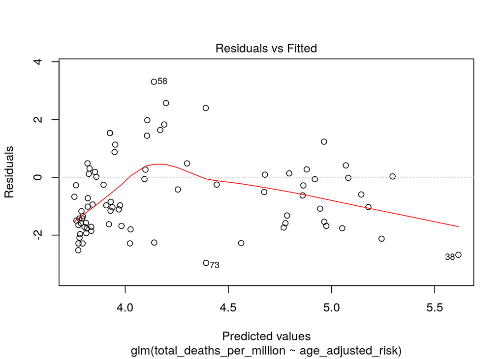

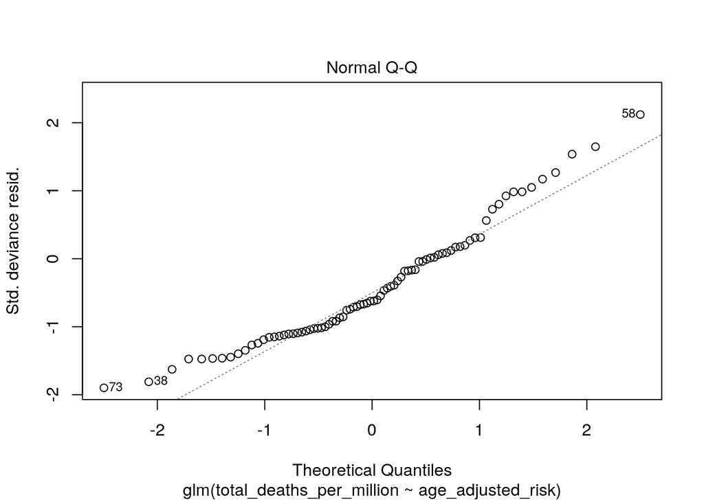

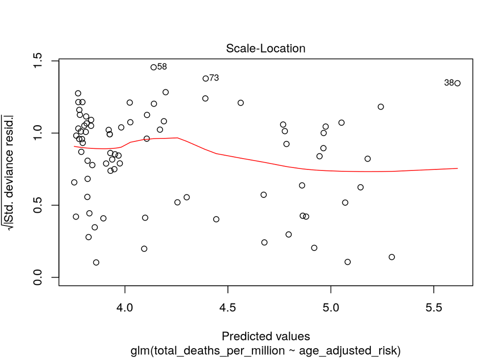

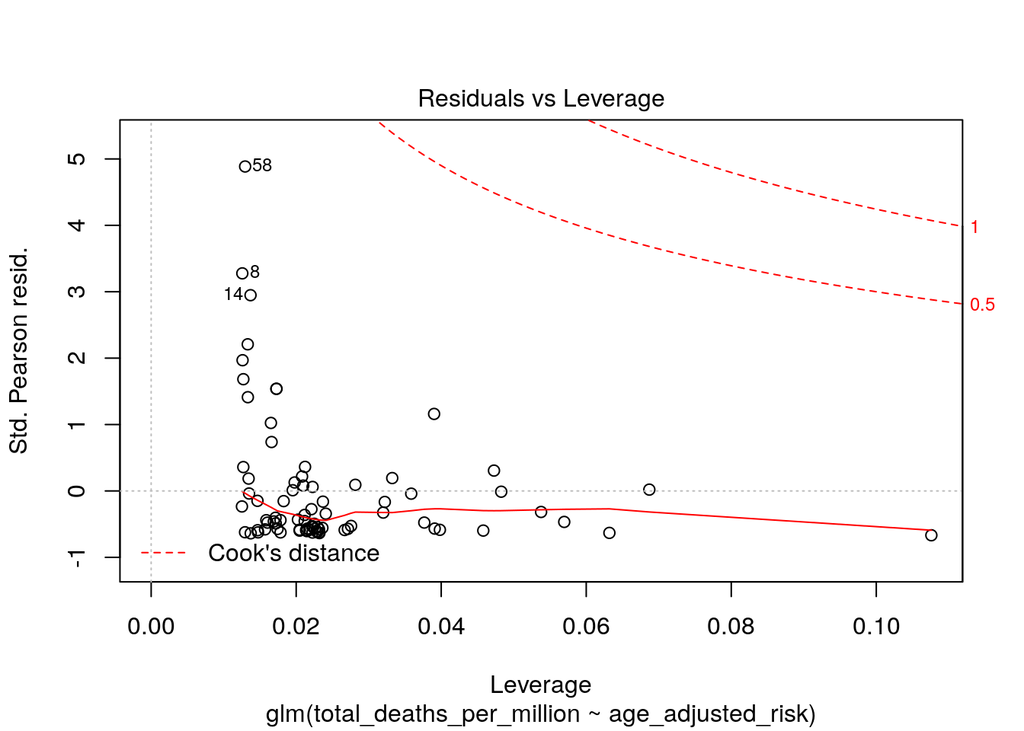

```r
plot(m1)
```

# Model 2: Predict total_deaths_per_million using age_adjusted_risk and Obesity_rate

```r
m2 <- glm(data = model_variables, family = Gamma("log"), formula = total_deaths_per_million ~ Obesity_rate + age_adjusted_risk)

summary(m2)
```

```
##
## Call:
## glm(formula = total_deaths_per_million ~ Obesity_rate + age_adjusted_risk,
##     family = Gamma("log"), data = model_variables)
##
## Deviance Residuals:
##     Min       1Q   Median       3Q      Max
## -2.5785  -1.4482  -0.6726   0.2865   3.5482
##
## Coefficients:
##                   Estimate Std. Error t value Pr(>|t|)
## (Intercept)       1.314969   0.406319   3.236  0.00179 **
## Obesity_rate      0.124199   0.019492   6.372 1.25e-08 ***
## age_adjusted_risk 0.008264   0.005058   1.634  0.10642
## ---
## Signif. codes:  0 '***' 0.001 '**' 0.01 '*' 0.05 '.' 0.1 ' ' 1
##
## (Dispersion parameter for Gamma family taken to be 2.224928)
##
##     Null deviance: 189.13  on 79  degrees of freedom
## Residual deviance: 136.48  on 77  degrees of freedom
## AIC: 800.45
##
## Number of Fisher Scoring iterations: 10
```

## Compare fitted values to actual values

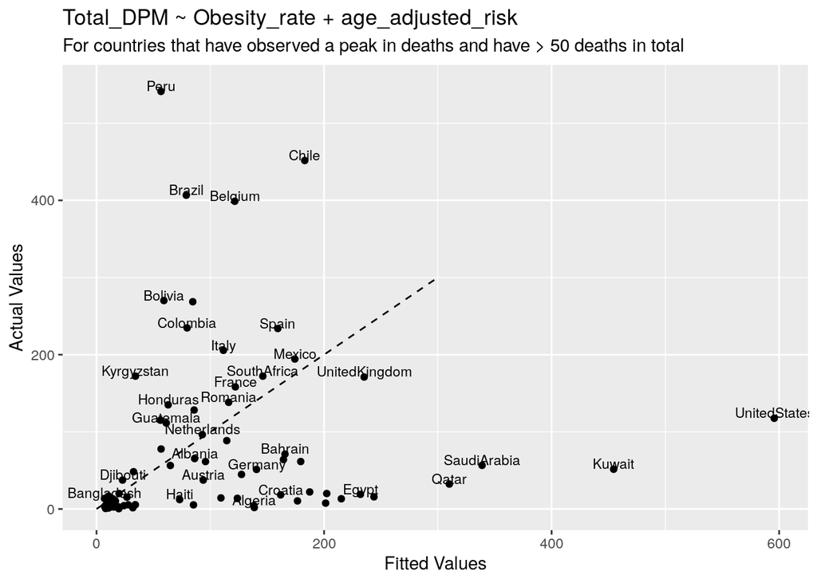

```r
ggplot(data = model_variables, aes(x = m2$fitted.values, y = total_deaths_per_million)) +
  geom_point() +
  geom_text(aes(label = Country), size = 3, check_overlap = T, nudge_y = 7) +
  geom_line(aes(y = seq(0, 300, length.out = dim(model_variables)[1]), x = seq(0, 300, length.out = dim(model_variables)[1])), linetype = "dashed") +
  labs(title = "Total_DPM ~ Obesity_rate + age_adjusted_risk",
       subtitle = "For countries that have observed a peak in deaths and have > 50 deaths in total",
       x = "Fitted Values",
       y = "Actual Values")
```

## Check residuals

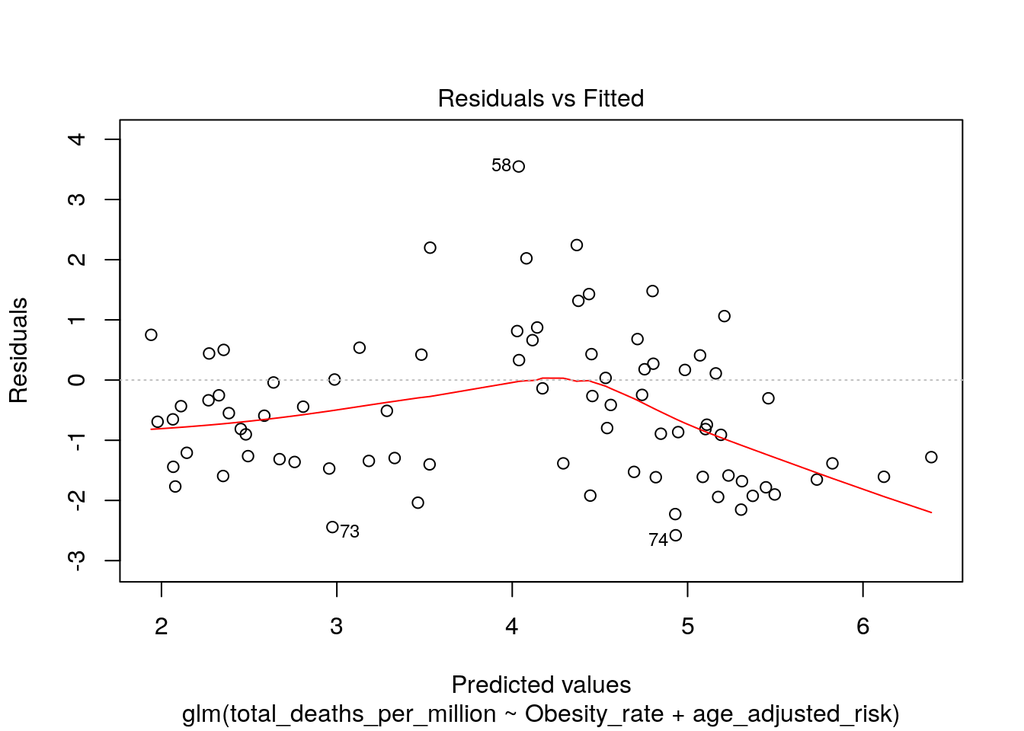

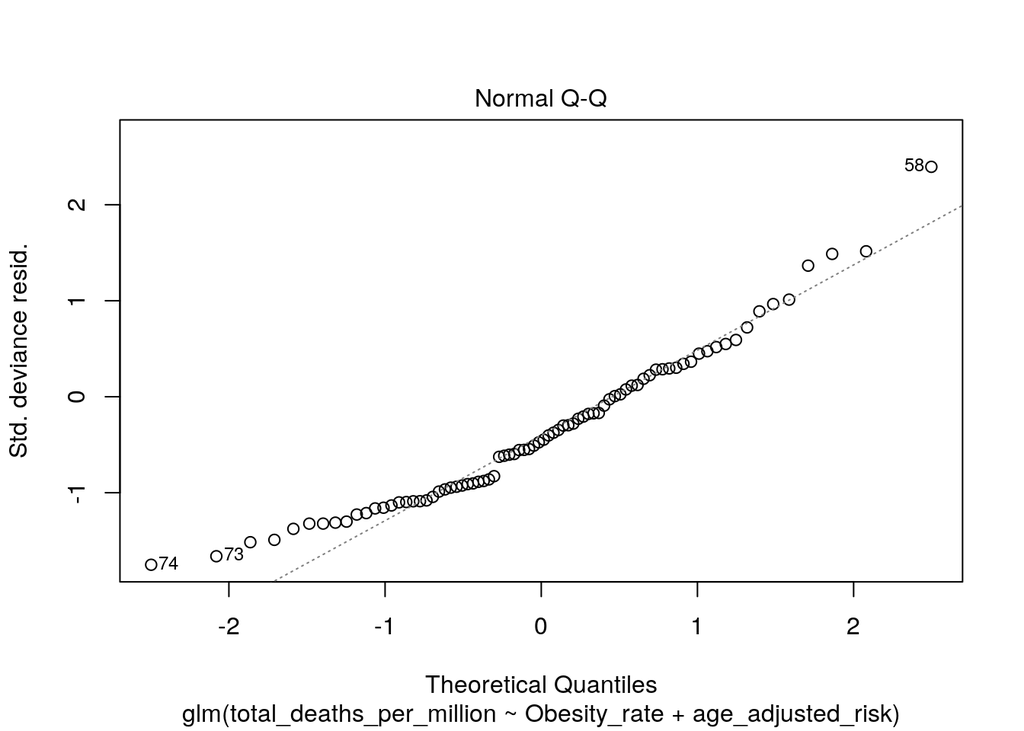

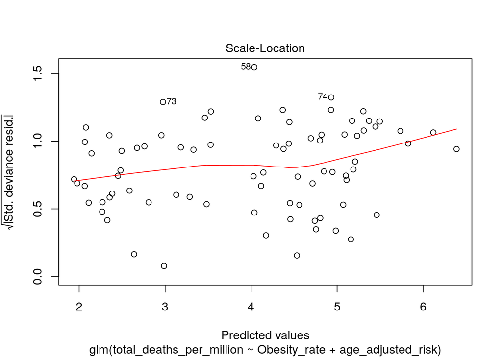

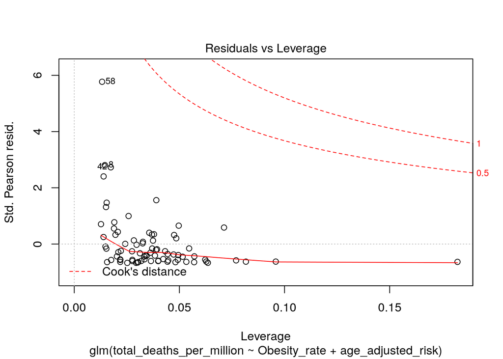

```r
plot(m2)
```

# Model 3: Predict total_deaths_per_million using age_adjusted_risk, Obesity_rate, and Inequality_spatial_transformed

```r
m3 <- glm(data = model_variables, family = Gamma("log"),
          formula = total_deaths_per_million ~ Obesity_rate + age_adjusted_risk + Inequality_spatial_transformed)

# Worse models
# m3b <- glm(data = model_variables, family = Gamma("log"),
#           formula = total_deaths_per_million ~ Obesity_rate + Inequality_spatial_transformed)
#
# m3c <- glm(data = model_variables, family = Gamma("log"),
#           formula = total_deaths_per_million ~ Obesity_rate + age_adjusted_risk + combined_density_measure)

summary(m3)
```

```
##
## Call:
## glm(formula = total_deaths_per_million ~ Obesity_rate + age_adjusted_risk +
##     Inequality_spatial_transformed, family = Gamma("log"), data = model_variables)
##
## Deviance Residuals:
##     Min       1Q   Median       3Q      Max
## -2.5659  -1.4652  -0.6898   0.2949   3.5225
##
## Coefficients:
##                                Estimate Std. Error t value Pr(>|t|)
## (Intercept)                    1.287271   0.425802   3.023  0.00341 **
## Obesity_rate                   0.122457   0.020185   6.067 4.73e-08 ***
## age_adjusted_risk              0.008676   0.005292   1.640  0.10522
## Inequality_spatial_transformed 0.006836   0.025552   0.268  0.78978
## ---
## Signif. codes:  0 '***' 0.001 '**' 0.01 '*' 0.05 '.' 0.1 ' ' 1
##
## (Dispersion parameter for Gamma family taken to be 2.227593)
##
##     Null deviance: 189.13  on 79  degrees of freedom
## Residual deviance: 136.40  on 76  degrees of freedom
## AIC: 802.39
##
## Number of Fisher Scoring iterations: 12
```

## Compare fitted values to actual values

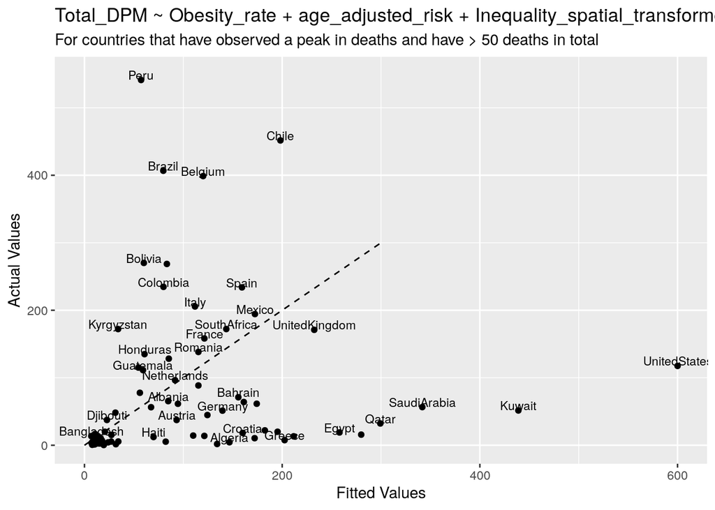

```r
ggplot(data = model_variables, aes(x = m3$fitted.values, y = total_deaths_per_million)) +
  geom_point() +
  geom_text(aes(label = Country), size = 3, check_overlap = T, nudge_y = 7) +
  geom_line(aes(y = seq(0, 300, length.out = dim(model_variables)[1]), x = seq(0, 300, length.out = dim(model_variables)[1])), linetype = "dashed") +
  labs(title = "Total_DPM ~ Obesity_rate + age_adjusted_risk + Inequality_spatial_transformed",
       subtitle = "For countries that have observed a peak in deaths and have > 50 deaths in total",
       x = "Fitted Values",
       y = "Actual Values")
```

## Check residuals

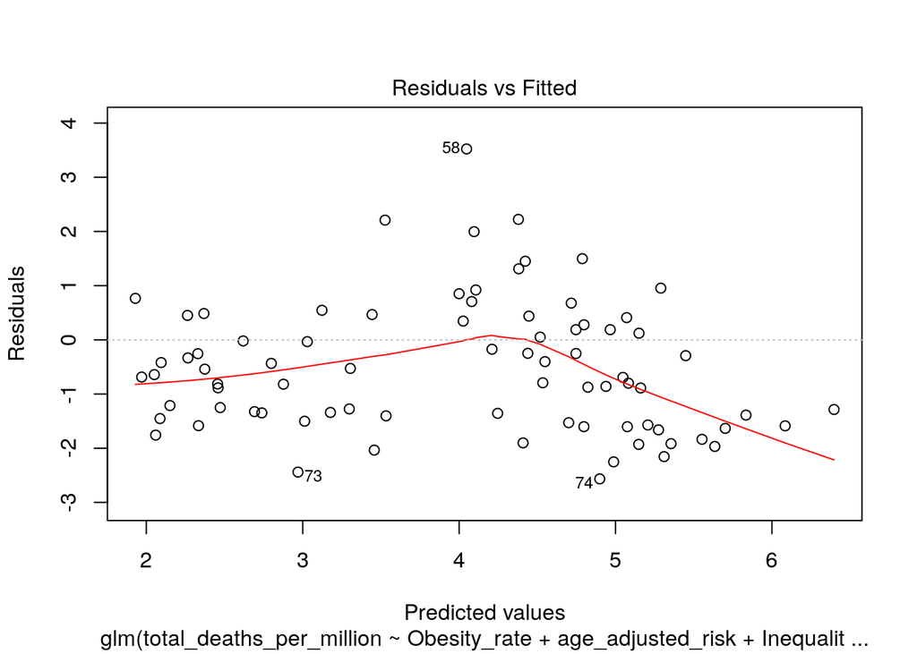

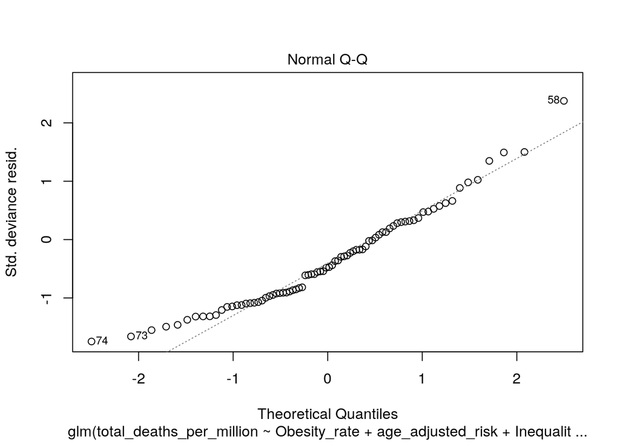

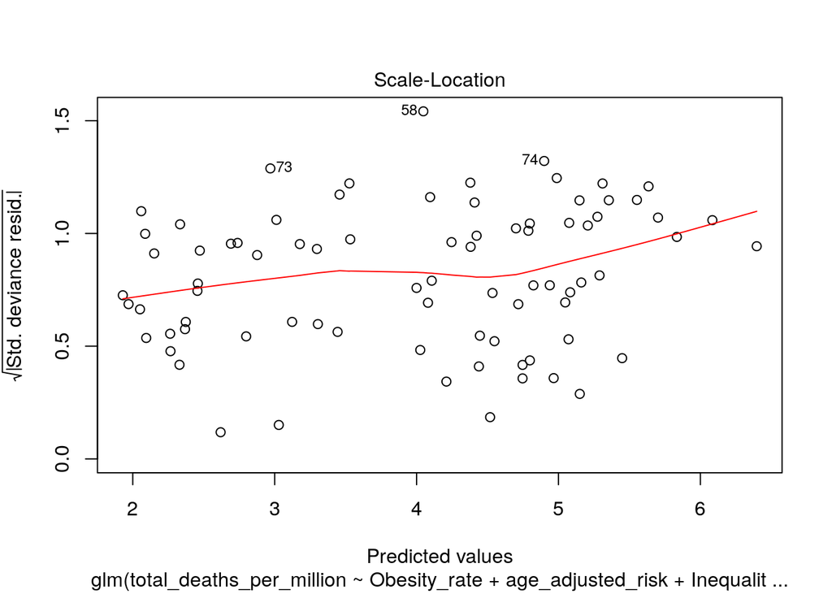

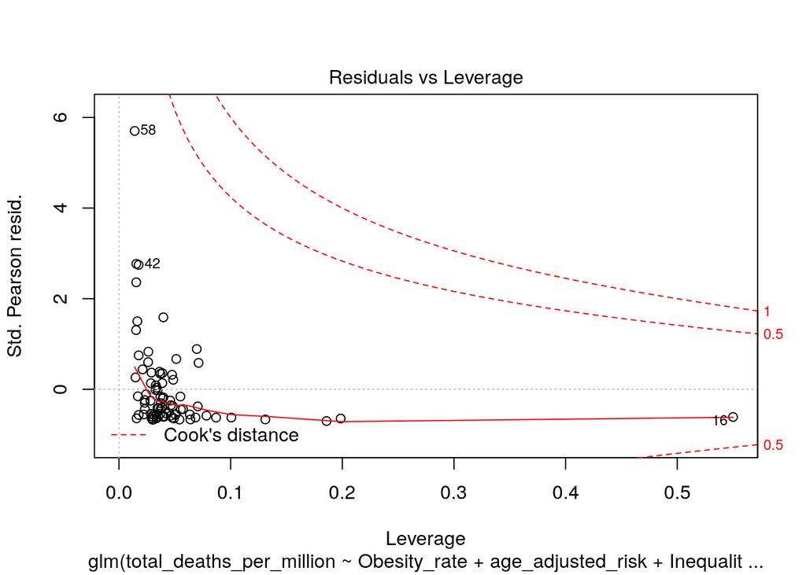

```r
plot(m3)
```

# Model 4: Predict total_deaths_per_million using age_adjusted_risk, Obesity_rate, and gov_response_at_0.1_deaths_per_million

```r
# Include gov response data
m4 <- glm(data = model_variables, family = Gamma("log"), formula = total_deaths_per_million ~ Obesity_rate + age_adjusted_risk + gov_response_at_0.1_deaths_per_million)

summary(m4)
```

```
##
## Call:
## glm(formula = total_deaths_per_million ~ Obesity_rate + age_adjusted_risk +
##     gov_response_at_0.1_deaths_per_million, family = Gamma("log"),
##     data = model_variables)
##
## Deviance Residuals:
##     Min       1Q   Median       3Q      Max
## -2.6284  -1.4700  -0.6643   0.2937   3.1971
##
## Coefficients:
##                                        Estimate Std. Error t value Pr(>|t|)
## (Intercept)                            0.734105   0.681481   1.077   0.2848
## Obesity_rate                           0.124833   0.018568   6.723 2.91e-09 ***
## age_adjusted_risk                      0.011668   0.005128   2.275   0.0257 *
## gov_response_at_0.1_deaths_per_million 0.006411   0.007038   0.911   0.3652
## ---
## Signif. codes:  0 '***' 0.001 '**' 0.01 '*' 0.05 '.' 0.1 ' ' 1
##
## (Dispersion parameter for Gamma family taken to be 2.006107)
##
##     Null deviance: 189.13  on 79  degrees of freedom
## Residual deviance: 134.54  on 76  degrees of freedom
## AIC: 801.03
##
## Number of Fisher Scoring iterations: 11
```

## Compare fitted values to actual values

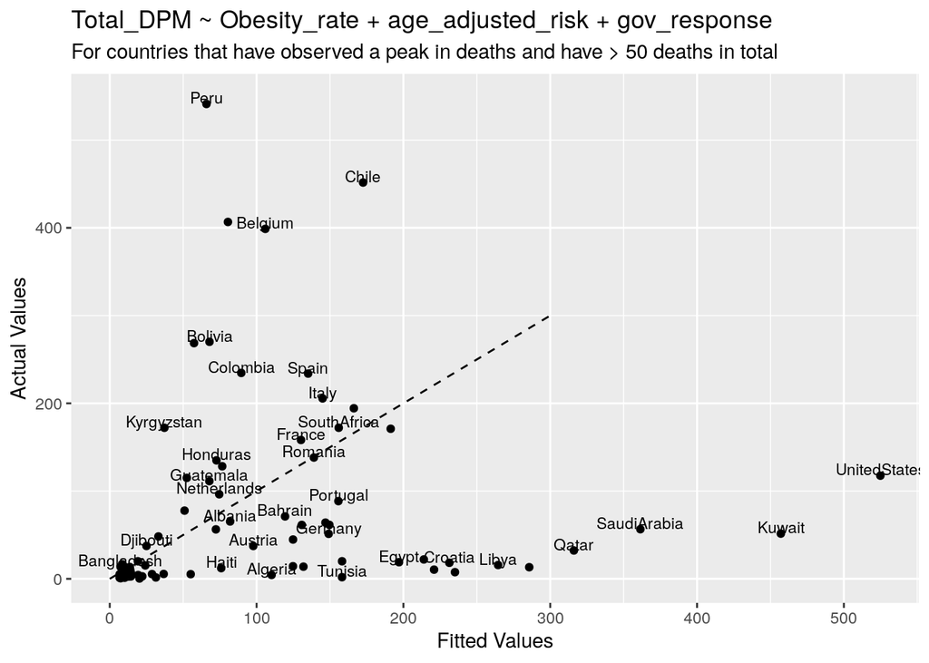

```r
ggplot(data = model_variables, aes(x = m4$fitted.values, y = total_deaths_per_million)) +
  geom_point() +
  geom_text(aes(label = Country), size = 3, check_overlap = T, nudge_y = 7) +
  geom_line(aes(y = seq(0, 300, length.out = dim(model_variables)[1]), x = seq(0, 300, length.out = dim(model_variables)[1])), linetype = "dashed") +
  labs(title = "Total_DPM ~ Obesity_rate + age_adjusted_risk + gov_response",
       subtitle = "For countries that have observed a peak in deaths and have > 50 deaths in total",
       x = "Fitted Values",
       y = "Actual Values")
```

## Check residuals

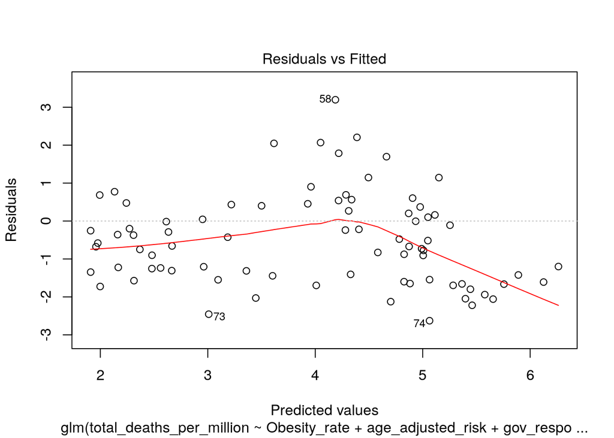

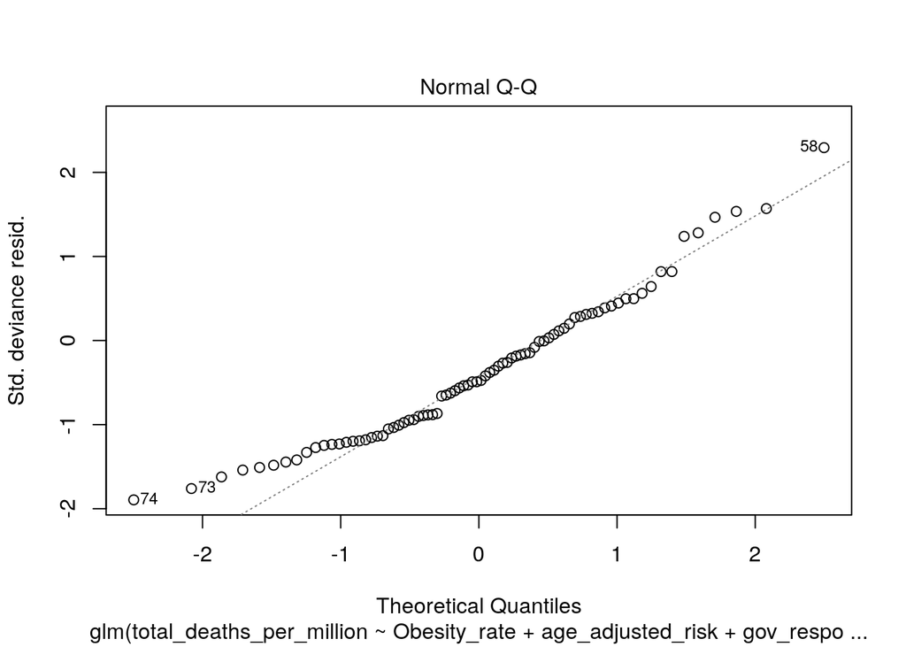

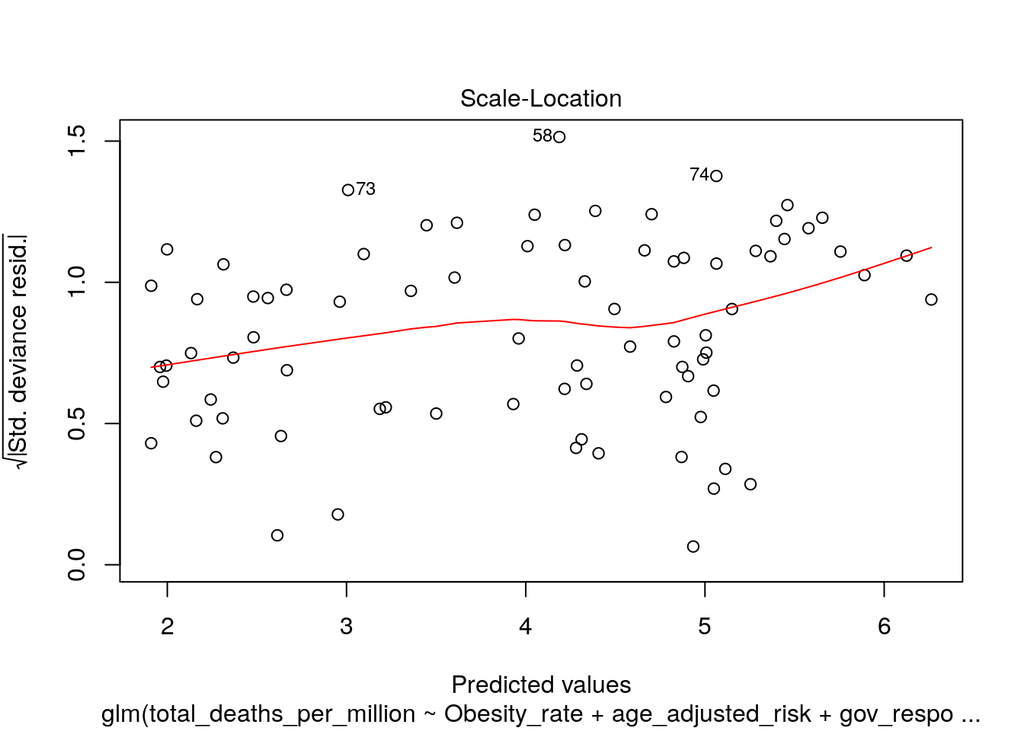

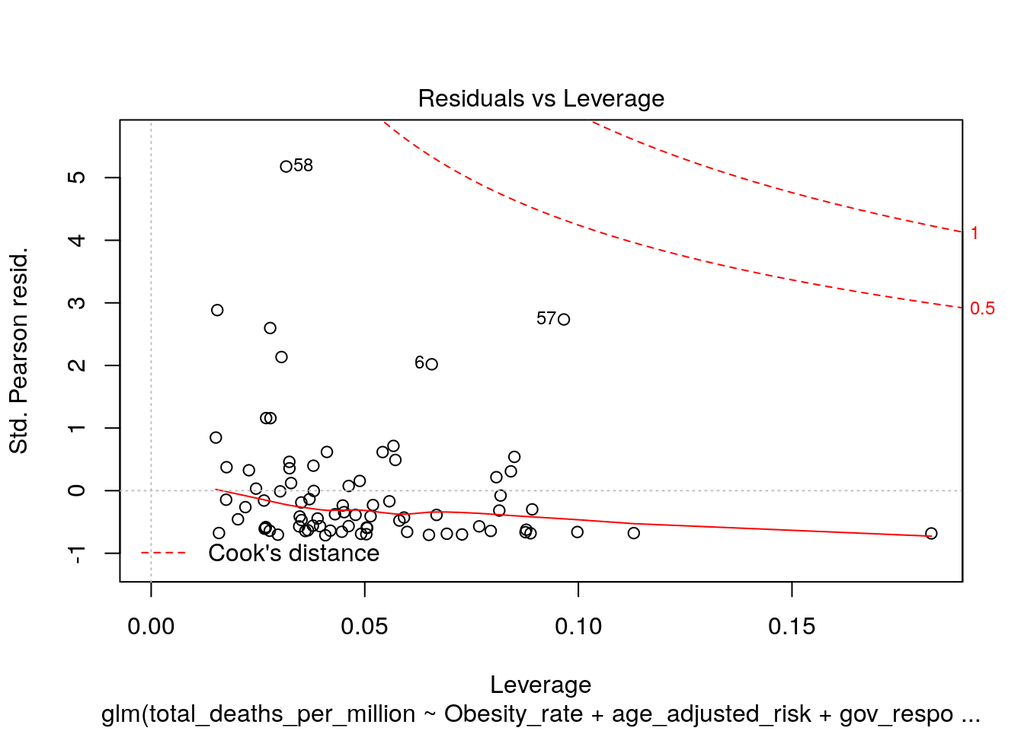

```r
plot(m4)
```

# Model 5: Predict total_deaths_per_million using age_adjusted_risk, Obesity_rate, Inequality_spatial_transformed, and gov_response_at_0.1_deaths_per_million

```r
# Include all of above
m5 <- glm(data = model_variables, family = Gamma("log"),
          formula = total_deaths_per_million ~ Obesity_rate + age_adjusted_risk + gov_response_at_0.1_deaths_per_million + Inequality_spatial_transformed)

# Worse model
# m5b <- glm(data = model_variables, family = Gamma("log"),
#           formula = total_deaths_per_million ~ Obesity_rate + age_adjusted_risk + gdp_estimate_ppp + average_gov_response + Inequality_spatial_transformed)

summary(m5)
```

```
##
## Call:
## glm(formula = total_deaths_per_million ~ Obesity_rate + age_adjusted_risk +
##     gov_response_at_0.1_deaths_per_million + Inequality_spatial_transformed,
##     family = Gamma("log"), data = model_variables)
##
## Deviance Residuals:
##     Min       1Q   Median       3Q      Max
## -2.6247  -1.4691  -0.6713   0.2957   3.1935
##
## Coefficients:
##                                        Estimate Std. Error t value Pr(>|t|)
## (Intercept)                            0.731489   0.688159   1.063   0.2912
## Obesity_rate                           0.124362   0.019370   6.420 1.11e-08 ***
## age_adjusted_risk                      0.011751   0.005317   2.210   0.0301 *
## gov_response_at_0.1_deaths_per_million 0.006356   0.007118   0.893   0.3747
## Inequality_spatial_transformed         0.001847   0.024523   0.075   0.9402
## ---
## Signif. codes:  0 '***' 0.001 '**' 0.01 '*' 0.05 '.' 0.1 ' ' 1
##
## (Dispersion parameter for Gamma family taken to be 2.029103)
##
##     Null deviance: 189.13  on 79  degrees of freedom
## Residual deviance: 134.53  on 75  degrees of freedom
## AIC: 803.03
##
## Number of Fisher Scoring iterations: 11
```

## Compare fitted values to actual values

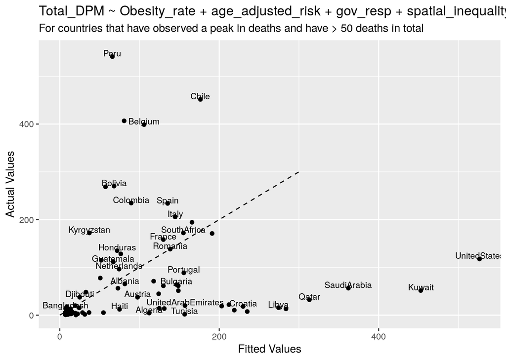

```r
ggplot(data = model_variables, aes(x = m5$fitted.values, y = total_deaths_per_million)) +
  geom_point() +
  geom_text(aes(label = Country), size = 3, check_overlap = T, nudge_y = 7) +
  geom_line(aes(y = seq(0, 300, length.out = dim(model_variables)[1]), x = seq(0, 300, length.out = dim(model_variables)[1])), linetype = "dashed") +
  labs(title = "Total_DPM ~ Obesity_rate + age_adjusted_risk + gov_resp + spatial_inequality",
       subtitle = "For countries that have observed a peak in deaths and have > 50 deaths in total",
       x = "Fitted Values",
       y = "Actual Values")
```

```r
ggsave("04_Results/Best_Fitted_vs_Actual_Values.png")
```

## Predict total_deaths_per_million for countries not included in the model

```r
predictions <- add_pi(tb = simple_model_data %>%
                             filter(!(Country %in% model_variables$Country) & date == "2020-05-11") %>%
                             mutate(total_deaths_per_million = 0), fit = m5) %>%
                 select(Country, pred, LPB0.025, UPB0.975) %>%
                 rename(Predicted_total_deaths_at_peak = pred)
write.csv(predictions, "04_Results/best_model_predictions_for_out_of_sample_countries.csv")

# Compare fits of countries included to actual values - table
fits <- cbind.data.frame(model_variables %>%
                           ungroup() %>%
                           select(Country, total_deaths_per_million), m5$fitted.values) %>%
                           rename(Fitted_Values = `m5$fitted.values`,
                                  Actual_values = total_deaths_per_million)

write.csv(fits, "04_Results/best_model_fits_for_in_sample_countries.csv")

# Correlation matrix of variables we included in model 5

as.data.frame(cor(model_variables %>% ungroup() %>% select(Obesity_rate, age_adjusted_risk, gdp_estimate_ppp, gov_response_at_0.1_deaths_per_million, Density_km, Inequality_spatial_transformed)))
```

```
##                                        Obesity_rate age_adjusted_risk gdp_estimate_ppp gov_response_at_0.1_deaths_per_million    Density_km
## Obesity_rate                             1.00000000      0.2597737188               NA                             -0.1692272  0.0224594298
## age_adjusted_risk                        0.25977372      1.0000000000               NA                             -0.3774327 -0.0000310452
## gdp_estimate_ppp                                 NA                NA                1                                     NA            NA
## gov_response_at_0.1_deaths_per_million  -0.16922719     -0.3774327210               NA                              1.0000000 -0.1916720140
## Density_km                               0.02245943     -0.0000310452               NA                             -0.1916720  1.0000000000
## Inequality_spatial_transformed           0.18238937     -0.2296810062               NA                              0.1593158 -0.1430932885
##                                        Inequality_spatial_transformed
## Obesity_rate                                                0.1823894
## age_adjusted_risk                                          -0.2296810
## gdp_estimate_ppp                                                   NA
## gov_response_at_0.1_deaths_per_million                      0.1593158
## Density_km                                                 -0.1430933
## Inequality_spatial_transformed                              1.0000000
```

## Check residuals

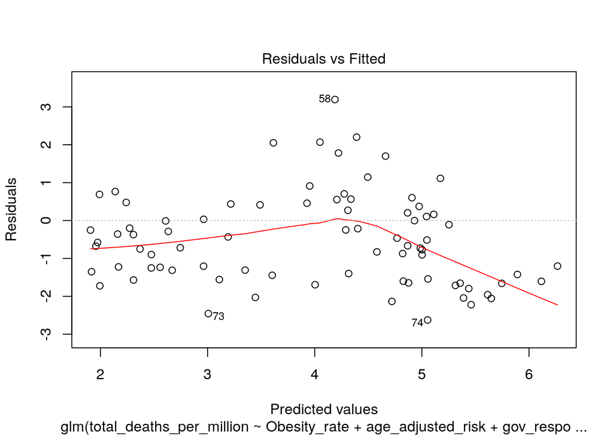

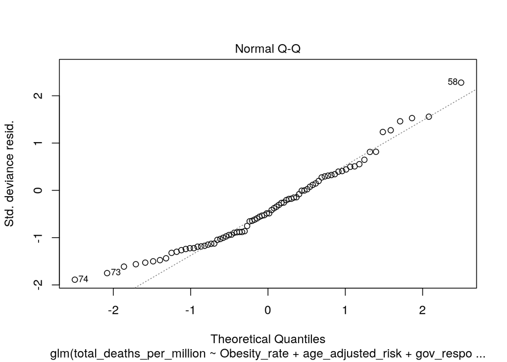

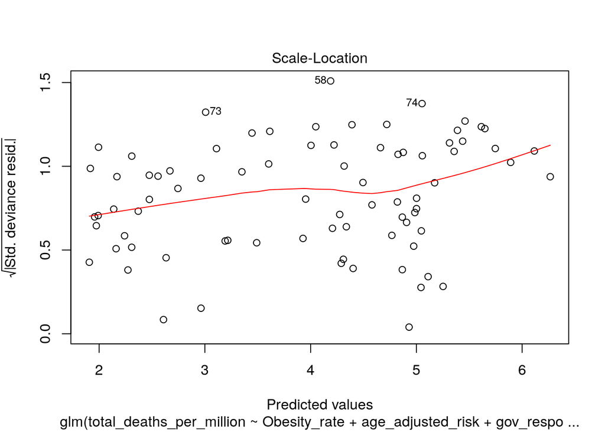

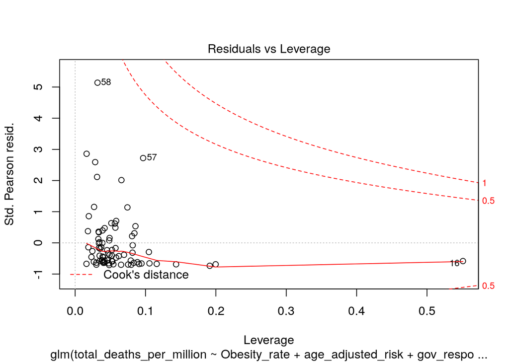

```r
plot(m5)
```